# Fine-mapping inflammatory bowel disease loci to single-variant resolution

Hailiang Huang, Ming Fang, Luke Jostins, Maša Umićević Mirkov, Gabrielle Boucher, Carl A. Anderson, Vibeke Andersen, Isabelle Cleynen, Adrian Cortes, François Crins, Mauro D’Amato, Valérie Deffontaine, Julia Dmitrieva, Elisa Docampo, Mahmoud Elansary, Kyle Kai-How Farh, Andre Franke, Ann-Stephan Gori, Philippe Goyette, Jonas Halfvarson, Talin Haritunians, Jo Knight, Ian C. Lawrance, Charlie W. Lees, Edouard Louis, Rob Mariman, Theo Meuwissen, Myriam Mni, Yukihide Momozawa, Miles Parkes, Sarah L. Spain, Emilie Théâtre, Gosia Trynka, Jack Satsangi, Suzanne van Sommeren, Severine Vermeire, Ramnik J. Xavier, International Inflammatory Bowel Disease Genetics Consortium, Rinse K. Weersma, Richard H. Duerr, Christopher G. Mathew, John D. Rioux, Dermot P. B. McGovern, Judy H. Cho, Michel Georges, Mark J. Daly & Jeffrey C. Barrett

Nature volume 547, pages173–178(2017)

Online paper [link](https://www.nature.com/articles/nature22969)

## Background

Inflammatory bowel diseases (IBD)

- IBD is a group of chronic gastrointestinal inflammatory disorders
- IBD affects millions worldwide, and is rising in prevalence
- IBD has two subtypes: ulcerative colitis (UC) and Crohn’s disease (CD)
- GWAS identified 200 IBD-associated loci, but few have been conclusively resolved to specific functional variants.
- linkage disequilibrium (LD) often results in similar evidence for association among many neighboring variants, difficult to resolve causal variants.

## Methods

### Fine-mapping method 1

Step 1: model selection of independent signals

- Bayesian information criterion (BIC)-based selection
- Penalized maximum likelihood across traits and variants
- Greedy search algorithm (steepest descent approximation)
- A swap-out repositioning adjustment

Step 2: construction of confident sets (CS)

- 95% CSs contain exactly one signal
- Conditional CS in the presence of multiple signals
- Potentially multiple CS generated per region

### Fine-mapping method 2

Step 1: use multinomial likelihood with correlated normal prior on the effect sizes

- Assume all loci are shared between traits
- Leverage the strong correlation in effect size
- directly calculates maximum apriori model estimates

Step 2: mapping secondary association signal

- Conditional regression followed by Step 1
- Stopping criteria: number of signals by method 1

### Fine-mapping method 3

Step 1: Bayesian LASSO

- Multiple causal variants jointly using a LASSO prior
- Sample from posterior rather than computing it
  - Sample y from liability threshold model
  - Sample configuration restricted to clusters
  - Sample parameters and hyperparameters (Gibbs)
- Get CS from posterior samples for each cluster

Step 2: cross trait CS construction

- Simply merge overlapping clusters

## Results

### Enrichment and colocalization

- Protein coding variants
  - 18-fold enrichment in non-synonymous
  - Only one variant with >50% certainty is synonymous
  - All previously reported IBD risk coding variants are included with >95% certainty

### Fine-mapping summary

- Among 97 IBD-associated loci, 94 identified consistent CS, 45 variants significantly enriched for protein-coding changes
- Size of CS: range from 1 to >400 variants
- 18 single causal variants with >95% certainty, of which 13 are novel
- 27 single causal variants with >50% certainty
- Most variants are associated with both UC and CD
- Number of potaneial candidate genes is reduced from 669 to 233

### Proportion of variance explained (PVE)

- CD: 25% CD risk explained by fine-mapping out of a total of 28% by all loci
- UC: 17% out of 22%

### Results of method 1

- Non-significant overlap of top PBMC eQTLs in CS identified
- Overlap of eQTLs for CD4+ cells and ileum cells observed

### Results of method 2

> /home/min/Downloads/m2.png (206.6 KiB):

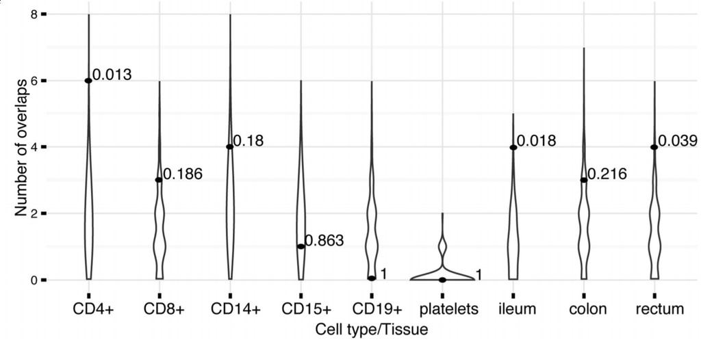

```python
%preview /home/min/Downloads/m2.png
```

Figure 4 in paper: Number of credible sets that colocalize eQTLs.

## Conclusions

- IBD associated variants significant enrichment in coding regions and strong immune signature
- Moderate, cell/tissue specific eQTL colocalization
- 21 non-coding variants in IBD CS not interpreted

## Discussions

- Direct genotyping of (common) causal variant is essential
- Improve fine-mapping resolution in other ethnicities, but not enough data to pursue

© 2016-2017 Min Qiao at [Xin He lab](http://xinhelab.org), The University of Chicago

Exported from [`analysis/20200703_Fine_mapping_IBD.ipynb`](http://github.com/gaow/cnv-gene-mapping/blob/345d6d20740960ff008d470162dca36910d6b8ab/analysis/20200703_Fine_mapping_IBD.ipynb) committed by minqiao on Wed Jul 8 15:22:52 2020 [revision 1, 345d6d2](http://github.com/gaow/cnv-gene-mapping/commit/345d6d20740960ff008d470162dca36910d6b8ab)